# Data Exploration on Kaggle's House Prices Dataset

## by Houssem Menhour

## Investigation Overview

In this presentation, I'll be showcasing some key findings from my EDA process on the dataset described bellow.

My main interest is finding out what features of a house decide its pricing.

## Dataset Overview

This is a popular dataset from Kaggle with historical sale prices of houses and their features or characteristics. It is meant for practicing regression techniques and predicting sale prices, a task that requires EDA first.

This dataset comes in 1460 entries and 81 columns, 38 of which are numerical while 43 are categorical. Some of the categorical columns represent ordinal values, this mainly applies to variables of a quality related value, while others are nominal.

The full data and its description is available [here](https://www.kaggle.com/c/house-prices-advanced-regression-techniques/data).

## A look at missing values in the dataset

The variables with too many missing values will be dropped, and the rest filled with mean or mode values.

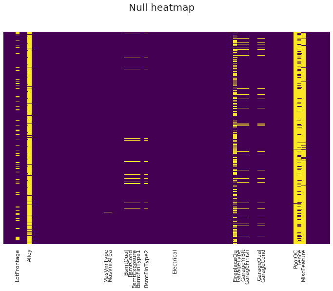

```python
#Display missing values
plt.figure(figsize=(12,8))
#plt.suptitle('Missing Values in the Dataset', fontsize=20)
sns.heatmap(df2.isnull(), yticklabels=False, xticklabels=label_nas ,cbar = False, cmap='viridis')
plt.suptitle('Null heatmap', fontsize=20)
plt.show()
```

## Distribution of Sale Prices

The original sale prices are skewed, we need to transform them to make it closer to a normal distribution.

Applying `np.log1p` significally reduces the skew value from 1.88 to 0.12.

The same transform will be applied to the other skewed numerical variables.

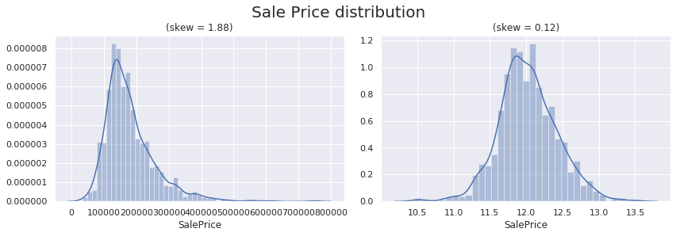

```python
skewness1 = df2['SalePrice'].skew()
skewness2 = np.log1p(df2['SalePrice']).skew()


f = plt.figure(figsize=(12, 4))
gs = f.add_gridspec(1, 2)

ax = f.add_subplot(gs[0,0])
ax = sns.distplot(df2['SalePrice'], color="b", kde=True);
ax.set(title="(skew = {})".format(round(skewness1,2)))

ax = f.add_subplot(gs[0,1])
ax = sns.distplot(np.log1p(df2['SalePrice']), color="b");
ax.set(title="(skew = {})".format(round(skewness2,2)))

f.suptitle('Sale Price distribution', y = 1.03, fontsize=20)
f.tight_layout()
```

## Correlation Heatmap

As part of understanding the data, we can create a correlation matrix to highlight relationships between the various numerical data. The correlation matrix is represented as a heatmap.

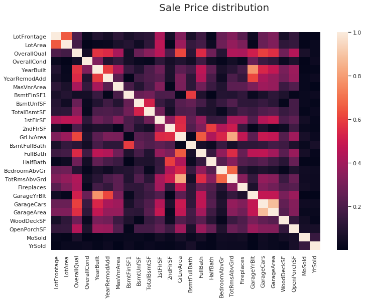

```python
#Correlation matrix between features
corr_mat = df2.drop(columns=["SalePrice"]).corr().abs()

#Plot the heatmap with seaborn
plt.figure(figsize=(12,8))
sns.heatmap(corr_mat,
        xticklabels=corr_mat.columns,
        yticklabels=corr_mat.columns)

plt.suptitle('Sale Price distribution', fontsize=20);
```

## Sale Price vs Quality Features

A high quality house should fetch a high price, this is proven by this data

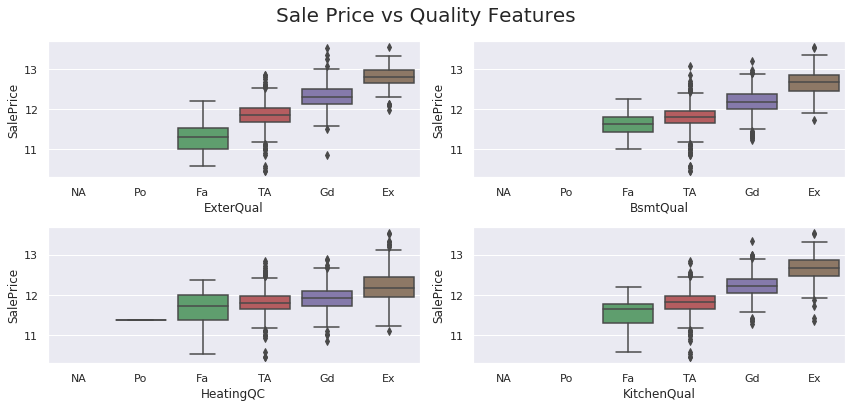

```python
col_interests = ['ExterQual', 'BsmtQual', 'HeatingQC', 'KitchenQual']

f = plt.figure(figsize=(12, 10))
gs = f.add_gridspec(len(col_interests), 2)
for i, col in enumerate(col_interests):
    ax = f.add_subplot(gs[int(i/2),i%2])
    ax = sns.boxplot(x=col, y="SalePrice", data=df2)
    #ax.set_xticklabels(ax.get_xticklabels(), ha = 'right', rotation=60)

f.suptitle('Sale Price vs Quality Features', y=1.03, fontsize=20)
f.tight_layout()
```

## Sale Price vs Overall Quality

Combining all the quality ratings in one score results in the following graph

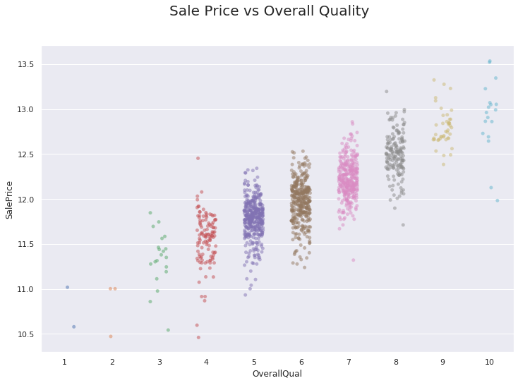

```python
f = plt.figure(figsize=(12, 8))
ax = sns.stripplot(x='OverallQual', y="SalePrice", data=df2, alpha = 0.5, jitter = 0.2)
f.suptitle('Sale Price vs Overall Quality', fontsize=20);
```

## Other Variables Affecting Sale Price

Quality is not the only factor, as expective the size of the house and age have a significant effect as well

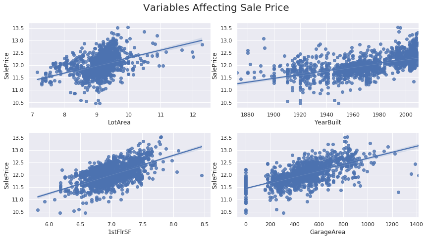

```python
col_interests = ['LotArea', 'YearBuilt', '1stFlrSF', 'GarageArea']

f = plt.figure(figsize=(12, 12))
gs = f.add_gridspec(len(col_interests), 2)
for i, col in enumerate(col_interests):
    ax = f.add_subplot(gs[int(i/2),i%2])
    ax = sns.regplot(x=col, y="SalePrice", data=df2)

f.suptitle('Variables Affecting Sale Price', y=1.03, fontsize=20)
f.tight_layout()
```

## Sale Price Determining Factors

This chart summarizes many of these factors in an easy to read way

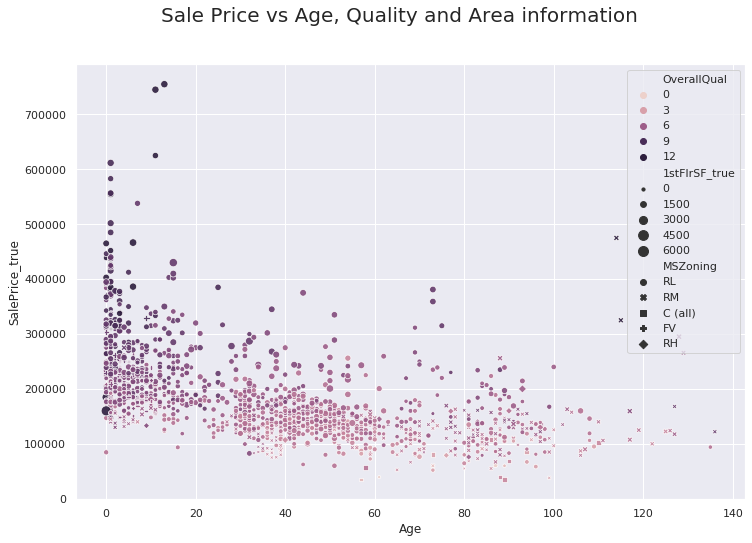

```python
f = plt.figure(figsize=(12, 8))
ax = sns.scatterplot(x='Age', y="SalePrice_true", hue='OverallQual', style='MSZoning', size='1stFlrSF_true', sizes=(10, 100),  data=df2, alpha = 0.9)
f.suptitle('Sale Price vs Age, Quality and Area information', fontsize=20);
```